# ARIMA models for time series

In previous posts we focused on analyzing the cross section of stock returns, which provides answers to questions such as why does a given stock have higher/lower returns than another stock, for example. This is done by breaking down returns of stocks (or portfolios) into risk factors, and regressing the returns on the factors with the use of linear models. This results in the investing approach known as factor investing.

Another fundamental aspect of asset returns is how returns for a same asset relate to each other over time. The collection of asset returns along time consists a financial time series.

```python
import numpy as np
import pandas as pd
import matplotlib.pyplot as plt
import scipy.stats as st
import statsmodels.api as sm
import yfinance as yf
import pymc as pm
import arviz as az
%matplotlib inline
```

[output not shown]

Time series data consists of data observed that is indexed along time. The time interval between points are generally a time unit, such as a day, month, year and so on. It differs from cross sectional data in that cross section analysis usually seeks to study the relation between different variables, and time series looks at values of a variable as functions of past observed values.

Cross sections can also have observations indexed along time, but crucial to it is the assumption that the different observations are independent of each other. Time series models can allow for dependence on past observed values, in this context known as autocorrelation.

In a similar way to the statistical correlation between two different variables, the statistical correlation between the current and past observed values along time for the same variable is known as autocorrelation. The formula for both is also similar, although the obtention of time series autocorrelation depends on the assumption of weak stationarity.

Stationarity, on its weak form, mean that both the mean and variance for the random variable is time invariant, i.e., does not change over time. Therefore, in a (weakly) stationary time series, the mean is a constant and the covariance between two points depends on a constant variance and the distance between those two points, so that the covariance is scaled to the distance between the two points.

In classical statistics, for any time series we can use statistical tests to verify the stationarity hypothesis, after obtaining the autocorrelation function (ACF). An example of such statistical test is the Ljung-Box test.

Let's try to obtain the ACF for a time series and perform the Ljung-Box test

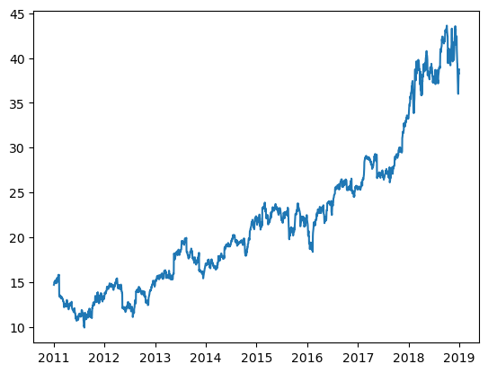

```python
start_date = "2011-01-01"
end_date = "2019-01-01"

csco = yf.Ticker("CSCO").history(start = start_date, end = end_date)["Close"]
plt.plot(csco)
```

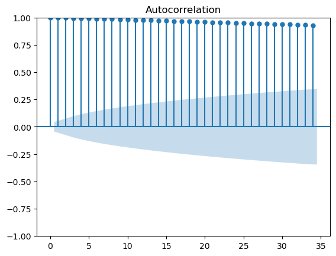

```python
sm.graphics.tsa.plot_acf(csco.values)
plt.show()
```

```python
### Calculate the Ljung-Box test statistics (Q) for each lag

acf_values = sm.tsa.stattools.acf(csco.values)

lb_test = sm.tsa.stattools.q_stat(acf_values, len(csco))
print("Q statistics for successive lags: " + str(lb_test[0].round(0)))
print("p-values for successive lags: " + str(lb_test[1].round(0)))
```

```
Q statistics for successive lags: [ 2015.  4023.  6024.  8018. 10006. 11988. 13964. 15933. 17896. 19851.
 21800. 23741. 25674. 27599. 29516. 31426. 33329. 35224. 37112. 38991.
 40862. 42725. 44581. 46430. 48272. 50108. 51937. 53760. 55576. 57384.
 59185. 60980. 62768. 64550.]
p-values for successive lags: [0. 0. 0. 0. 0. 0. 0. 0. 0. 0. 0. 0. 0. 0. 0. 0. 0. 0. 0. 0. 0. 0. 0. 0.
 0. 0. 0. 0. 0. 0. 0. 0. 0. 0.]
```

The test indicates a very high and persistent autocorrelation

A particular type of time series known as white noise consists of identically and independent distributed (IID) random variables, with finite mean and variance. Furthermore, when these random variables follow a normal distribution, they are called Gaussian white noise. As they are independently distributed, the computed ACF for a white noise process should have all of its values near zero.

In the case a time series has persistent autocorrelation, this means that past realized values might prove useful in predicting future values. A type of model that takes this into account is the autoregressive model, or AR, usually denoted as AR(p), where p is the number of lags included in the model.

An AR(1) model can be written as

$y_t = \alpha + \phi y_{t-1} + \varepsilon_t$,

where $\varepsilon_t$ is a white noise process with mean zero and finite variance $\sigma^2$. As the process is stationary, it will have a constant mean $\mu = \frac{\alpha}{1-\phi}$, however the stationarity condition $-1 < \phi < 1$ must always be verified.

Another type of useful model for data with autocorrelation is the moving average (MA) model. Unlike the AR model, for the MA the value of the observation $y_t$ is not a function of the past values of itself, but of the past random shocks. Moving average models are usually denoted as MA(q), with q being the number of lags for the past random shocks.

A MA(1) model has the form

$y_t = \alpha + \varepsilon_t - \theta \varepsilon_{t-1}$,

where $\varepsilon_t$ are the white noise random shocks with mean zero and finite variance. Moving average models are always stationary.

There is an uncanny relationship between AR and MA models where a MA(1) can be written as an AR(∞) model, and an AR(1) can also be written as a MA(∞). Let's start with a particular type of AR(∞) model

$y_t = - \theta y_{t-1} - \theta^2 y_{t-2} - \theta^3 y_{t-3} - \dots + \varepsilon_t$,

where the AR coefficient for lag $p$ is $\theta^p$, with $|\theta| <1$ and $\alpha = 0$. Introducing the lag operator $L$ so that $L^p y_t = y_{t-p}$, we can verify that

$y_t + \theta y_{t-1} + \theta^2 y_{t-2} + \theta^3 y_{t-3} + \dots = y_t + \theta L y_t + \theta^2 L^2 y_t + \theta^3 L^3 y_t + \dots = \frac{y_t}{1-\theta L} = \varepsilon_t$,

$y_t = (1-\theta L) \varepsilon_t = \varepsilon_t - \theta \varepsilon_{t-1}$,

which is the MA(1) model. Doing the same for the MA(∞) model

$y_t = \theta \varepsilon_{t-1} + \theta^2 \varepsilon_{t-2} + \theta^3 \varepsilon_{t-3} + \dots + \varepsilon_{t}$

$= \varepsilon_t + \theta L \varepsilon_t + \theta^2 L^2 \varepsilon_{t} + \theta^3 L^3 \varepsilon_{t} + \dots = \frac{\varepsilon_t}{1- \theta L}$

$= \theta y_{t-1} + \varepsilon_t$,

which is the AR(1) model.

Both AR and MA models can be combined in another type of model, ARMA. Usually denoted as ARMA(p,q), it has both p autoregressive terms and q moving average terms. An ARMA(1,1) model looks like

$y_t = \alpha + \phi y_{t-1} + \varepsilon_t - \theta \varepsilon_{t-1}$,

where we can note both the autoregressive and moving average terms.

Let's simulate the three types of processes and see what they look like

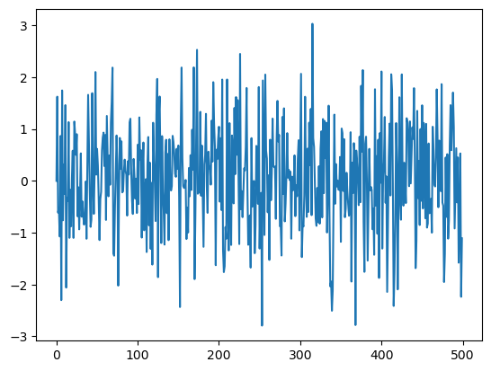

```python
np.random.seed(1)

### Simulating whine noise process with mean zero and variance 1

wn = np.empty(500)
wn[0] = 0
for i in range(0, len(wn)-1):
    wn[i+1] = np.random.randn()
plt.plot(wn)
```

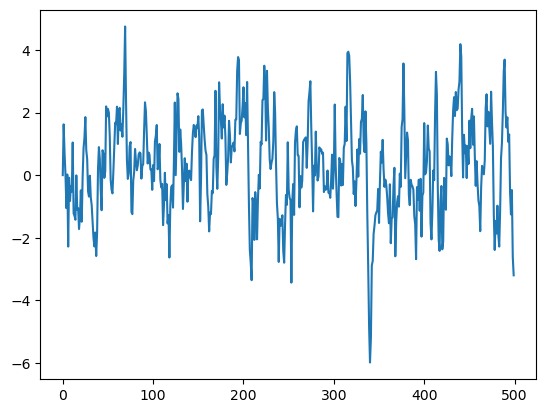

```python
np.random.seed(1)

### Simulating AR(1) process with mean zero and variance 1

phi = 0.8

ar = np.empty(500)
ar[0] = 0
for i in range(0, len(ar)-1):
    ar[i+1] = (phi * ar[i]) + np.random.randn()
plt.plot(ar)
```

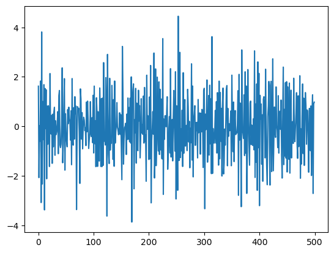

```python
np.random.seed(1)

### Simulating MA(1) process with mean zero and variance 1

theta = 0.9

ma = np.empty(500)
ma[0] = np.random.randn()
shock_past = ma[0]
for i in range(0, len(ma)-1):
    shock_current = np.random.randn()
    ma[i+1] = shock_current - (theta * shock_past)
    shock_past = shock_current
plt.plot(ma)
```

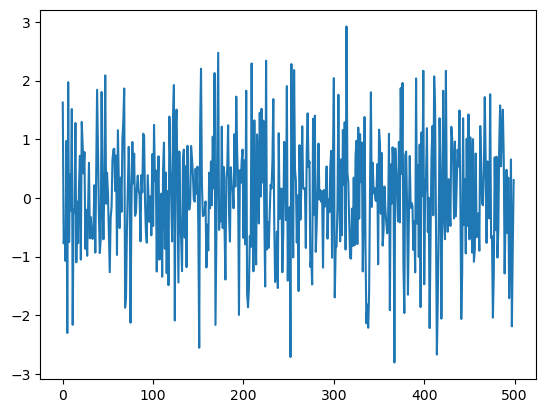

```python
np.random.seed(1)

### Simulating ARMA(1,1) process with mean zero and variance 1

phi = 0.8
theta = 0.9

arma = np.empty(500)
arma[0] = np.random.randn()
shock_past = arma[0]
for i in range(0, len(arma)-1):
    shock_current = np.random.randn()
    arma[i+1] = (phi * arma[i]) + shock_current - (theta * shock_past)
    shock_past = shock_current
plt.plot(arma)
```

At first glance, all three processes are similar. Depending on the AR and MA parameter values, it can be practically impossible to distinguish the process types from eyeballing only.

How do we know which model is the right one for our data, then? That will depend on the autocorrelation structure of our data. The already mentioned ACF, which is the measure of correlation between a series and past values of itself. Closely related is the partial ACF (PACF), which is similar to the ACF but removes the effects of intermediate correlations. For example, the ACF between observations $y_t$ and $y_{t-k}$ includes the effects of all intermediate lags $t-1, t-2, \ldots, t-k+1$ while the PACF between the same observations removes the effects of the intermediate lags.

The ACF and PACF are useful for identifying lags of MA and AR models, respectively. A strong ACF (PACF) spike at lag $k$ and PACF (ACF) with slow decay indicates the presence of a MA (AR) structure with $k$ lags. If both ACF and PACF have slow decay, this can show the presence of an ARMA structure, although the order of the ARMA model cannot be identified via ACF and PACF.

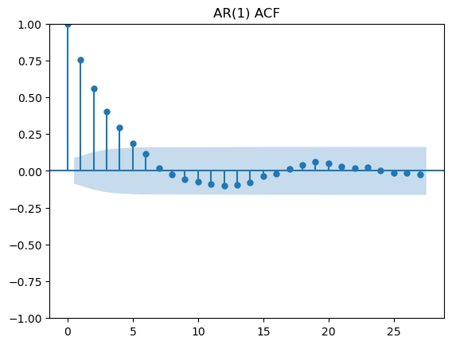

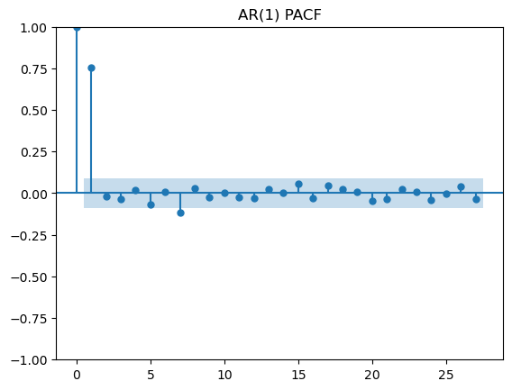

```python
# ACF and PACF for AR(1) process
# We should see a strong spike at lag 1 of the PACF and slowly decaying ACF

sm.graphics.tsa.plot_acf(ar)
plt.title("AR(1) ACF")

sm.graphics.tsa.plot_pacf(ar)
plt.title("AR(1) PACF")
plt.show()
```

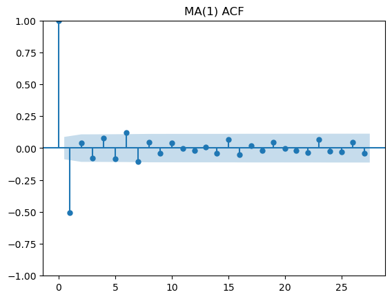

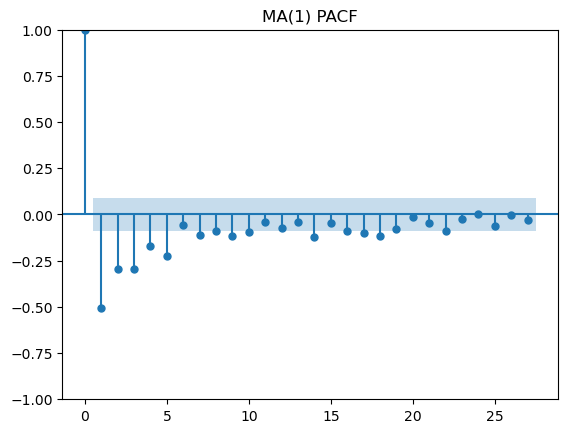

```python
# ACF and PACF for MA(1) process
# We should see a strong spike at lag 1 of the ACF and slowly decaying PACF

sm.graphics.tsa.plot_acf(ma)
plt.title("MA(1) ACF")

sm.graphics.tsa.plot_pacf(ma)
plt.title("MA(1) PACF")
plt.show()
```

The AR, MA and ARMA models require that the time series be stationary. The presence of nonstationarity brings some issues that we must be aware of, such as spurious correlations.

Let's try an experiment. We shall generate two time series that we know to be completely independent of each other:

$x_t = \alpha + x_{t-1} + \varepsilon_t$,

$y_t = \beta + y_{t-1} + u_t$,

$\varepsilon_t \sim N(0,\sigma^2)$, $u_t \sim N(0, \xi^2)$. In this case we know that $x_t$ and $y_t$ are completely independent of each other because $x_t$ does not enter the equation for the definition of $y_t$ and vice versa.

However, if we treat both time series as a cross section and estimate a linear regression model, we can observe a very high correlation.

This is a case where correlation does not imply causality, as the statistical correlation is very high but, as in this case we know the data generating processes behind $x_t$ and $y_t$, the causality is absent as the two processes are completely independent of each other.

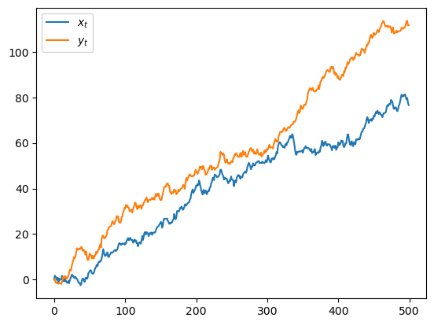

```python
np.random.seed(1)

### Simulating both series with constant mean and variance 1

alpha = 0.1
beta = 0.2

x_t = np.empty(500)
x_t[0] = 0
for i in range(0, len(x_t)-1):
    x_t[i+1] = alpha + x_t[i] + np.random.randn()
y_t = np.empty(500)
y_t[0] = 0
for i in range(0, len(y_t)-1):
    y_t[i+1] = beta + y_t[i] + np.random.randn()

plt.plot(x_t, label=r"$x_t$")
plt.plot(y_t, label=r"$y_t$")
plt.legend()
```

```python
# Treat series as cross section and estimate OLS

ols_model = sm.OLS(y_t, sm.add_constant(x_t)) # add_constant so that our model has an intercept
ols_results = ols_model.fit()
print(ols_results.summary())
```

```
                            OLS Regression Results
==============================================================================
Dep. Variable:                      y   R-squared:                       0.921
Model:                            OLS   Adj. R-squared:                  0.921
Method:                 Least Squares   F-statistic:                     5817.
Date:                Tue, 13 Sep 2022   Prob (F-statistic):          7.85e-277
Time:                        13:18:50   Log-Likelihood:                -1812.7
No. Observations:                 500   AIC:                             3629.
Df Residuals:                     498   BIC:                             3638.
Df Model:                           1
Covariance Type:            nonrobust
==============================================================================
                 coef    std err          t      P>|t|      [0.025      0.975]
------------------------------------------------------------------------------
const          3.6854      0.804      4.585      0.000       2.106       5.264
x1             1.3054      0.017     76.267      0.000       1.272       1.339
==============================================================================
Omnibus:                       86.782   Durbin-Watson:                   0.030
Prob(Omnibus):                  0.000   Jarque-Bera (JB):               27.376
Skew:                          -0.321   Prob(JB):                     1.14e-06
Kurtosis:                       2.050   Cond. No.                         92.7
==============================================================================

Notes:
[1] Standard Errors assume that the covariance matrix of the errors is correctly specified.
```

We observe a very high t-stat (and low p-value) for the regression coefficient.

When we have real data, we do not know the equations for the true data generating processes, however this example illustrates how both series having a trend will lead to high statistical (and possibly spurious) correlations between them.

In our example, both $x_t$ and $y_t$ are random walks with drifts. A random walk is one of the simplest examples of nonstationary time series. A random walk has the mathematical form

$y_t = y_{t-1} + \varepsilon_t$,

with $\varepsilon_t$ being Gaussian white noite. The RW can also be imagined as an AR(1) with $\phi = 1$. Remember: in order for the AR(1) to be stationary, the coefficient needs to be out of the unit circle, i.e., $|\phi| < 1$. If $\phi = 1$, the series is a random walk and if $|\phi| > 1$ the series is explosive.

The RW does not converge neither explode, but rather has a distinct behavior that can be visualized through two of its characteristics: the Markov and martingale properties.

The Markov property states that, in order to make predictions for a process $y_{t+s}$, with $s = 1,2,\ldots,\infty$, the only useful information is contained in the present value $y_t$, and therefore the past values such as $y_{t-1}$ or $y_{t-2}$ are useless for future predictions at instant $t$. In other words, a Markov process is memoryless.

The martingale property means that the expected value $E[y_{t+1}]$ given $y_t$ is equal to $y_t$. This is also known as the fair game property, because all expected future gains of a martingale lottery would be equal to the present gains.

The Markov and martingale properties are not equivalent to each other. A Markov process may not be a martingale, and vice versa. A random walk is both.

A RW with drift is similar, except it has the presence of a constant drift term:

$y_t = \mu + y_{t-1} + \varepsilon_t$,

with $\varepsilon_t$ also being Gaussian white noise. We say that both types of random walk have a stochastic trend due to the effect of the past observed values on subsequent values, e.g., the effect of $y_{t-1}$ on $y_t$.

Time series can also show a deterministic trend, such as the model

$y_t = \mu t + \varepsilon_t$.

The difference between both types of trend is that, for the stochastic trend models, the variance increases with the time window ($Var(y_t) = \sigma^2 t)$) while for the deterministic trend model it is constant ($Var(y_t) = \sigma^2)$.

We say series are trend stationary if after removing a deterministic trend, it becomes stationary. On the other hand, a series is said to be difference stationary if it becomes stationary after differencing, i.e., calculating its first difference. The first difference for a given value is the observed value minus the previous value.

In empirical applications, series are considered to be trend stationary if a fitted deterministic trend shows white noise residuals. Conversely, the series is considered difference stationary if a fitted stochastic trend shows white noise residuals.

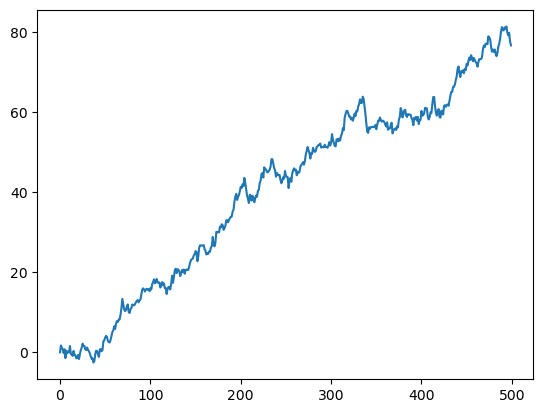

```python
np.random.seed(1)

### Simulating process with stochastic trend

mu = 0.1

s_trend = np.empty(500)
s_trend[0] = 0
for i in range(0, len(s_trend)-1):
    s_trend[i+1] = mu + s_trend[i] + np.random.randn()

plt.plot(s_trend)
```

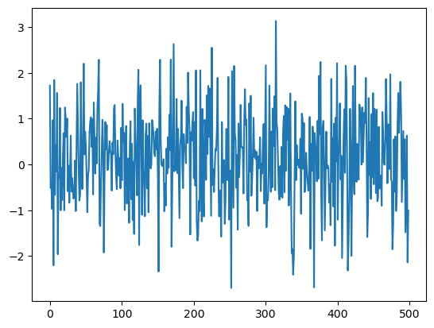

```python
# Differencing process with stochastic trend
# It should look like white noise

s_diff = np.diff(s_trend)
plt.plot(s_diff)
```

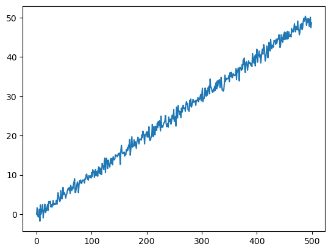

```python
np.random.seed(1)

### Simulating process with deterministic trend

mu = 0.1

d_trend = np.empty(500)
d_trend[0] = 0
for i in range(0, len(d_trend)-1):
    d_trend[i+1] = (mu * i) + np.random.randn()
plt.plot(d_trend)
```

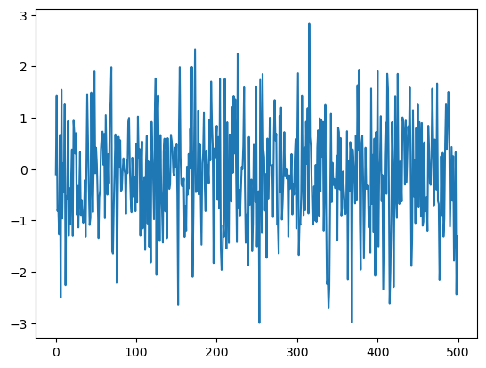

```python
# Removing deterministic trend from the deterministic trend process
# It should look like white noise

d_detrend = d_trend - (mu * np.arange(1, 501))
plt.plot(d_detrend)
```

A very important source of nonstationarity in time series are unit roots, such as in random walk models. Random walks, with or without drift, are unit root processes. Unit root processes are named like that because the characteristic equation for such processes has a root that lies in the unit circle. If a process has one autoregressive component, the coefficient for that component equals 1.

Unit roots introduce stochastic trends into time series, which makes standard estimates invalid because of spurious correlations. The stochastic trend can be removed by differencing, turning a nonstationary series into a stationary one. For example, say we have the random walk

$y_t = y_{t-1} + \varepsilon_t$.

The first difference

$\Delta y_t = y_t - y_{t-1}$

is stationary, in this case white noise because $\Delta y_t = \varepsilon_t$.

The amount of times a series has to be differenced to become stationary is known as the order of integration, denoted as I(d). Most nonstationary series, such as random walks, are I(1), meaning they need to be differenced only once in order to become stationary. Orders of integration of 2 and above are rare in practise. I(0) means a series is stationary.

Empirical time series can be checked for unit roots via statistical unit root tests. Examples of such tests are the ADF and KPSS tests.

```python
# ADF test with constant and drift
print("ADF test p-value: "  + str(sm.tsa.stattools.adfuller(csco, regression="c")[1]))

# KPSS test with constant and trend
print("KPSS test p-value: < "  + str(sm.tsa.stattools.kpss(csco, regression="ct")[1]))
```

```
ADF test p-value: 0.986645235883975
KPSS test p-value: < 0.01
```

Nonstationary time series can be modelled in a fashion similar to the ARMA approach with autoregressive integrated moving average (ARIMA) models. An ARIMA time series, denoted as ARIMA(p,d,q), is an I(d) time series whose d-th difference follows an ARMA(p,q) process. For example, a proces is ARIMA(1,1,1) if its first difference follows an ARMA(p,q) process.

Seasonality might also appear in time series, and can be dealt with through seasonal adjustments. One of the simplest types of seasonal adjustment is called seasonal differencing. For example, if a monthly time series $y_t$ has a seasonal period of 12, the seasonal difference is $y_t - y_{t-12}$.

Seasonal ARIMA (SARIMA) models can be specified by combining the ARIMA approach with seasonal adjustments. SARIMA models, denoted as SARIMA(p,d,q)(P,D,Q)$_m$, where (p,d,q) and (P,D,Q) are the ARIMA elements of the nonseasonal and seasonal components of the series, and $m$ stands for the seasonal period.

Exogenous regressors can also be specified for SARIMA models, resulting in the SARIMA with exogenous regressors (SARIMAX) models.

The Python library statsmodels can implement SARIMAX models with ease: https://www.statsmodels.org/stable/examples/notebooks/generated/statespace_sarimax_stata.html

Statsmodels also has a built-in function to simulate ARMA processes. Let's try to simulate and ARMA(1,1) process, obtain the corresponding ARIMA(1,1,1) and see what it looks like.

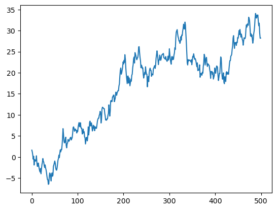

```python
np.random.seed(1)

### Simulate ARMA(1,1) process and calculate cumulative sum to obtain ARIMA(1,1,1)

phi = 0.8
theta = 0.9

arma_sample = sm.tsa.arma_generate_sample(ar = (1, phi), ma = (1, theta), nsample=500)
arima_sample = np.cumsum(arma_sample)

plt.plot(arima_sample)
```

The empirical procedure for fitting ARMA and ARIMA models is summarized in the Box-Jenkins approach:

1. Analyze the time series data for the presence of (non)stationarity and/or seasonality. This is conceptually akin to exploratory data analysis, and is carried out through the use of ACF and PACF functions. This step determines the order for all of the possible SARIMA elements.
2. Estimate the proposed model with statistical and computational methods.
3. Perform model diagnostics to make sure the residuals of the model follow a white noise process, and do not present autocorrelation. Both statistical tests, e.g. Ljung-Box test, and ACF/PACF plots are useful in this.

```
([], [])
```

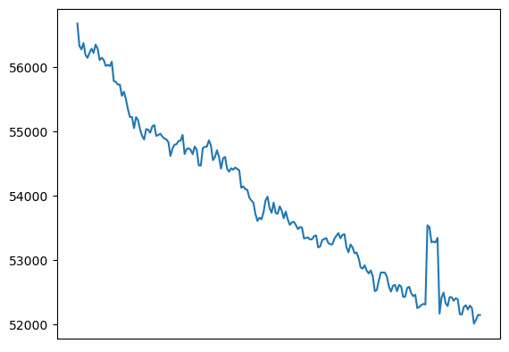

```python
shelter_data = pd.read_csv("https://data.cityofnewyork.us/api/views/k46n-sa2m/rows.csv?accessType=DOWNLOAD", index_col=0)["Total Individuals in Shelter"][2500:2700]
plt.plot(shelter_data)
plt.xticks([], [])
```

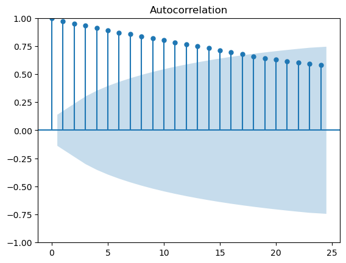

```python
sm.graphics.tsa.plot_acf(shelter_data.values)
plt.show()
```

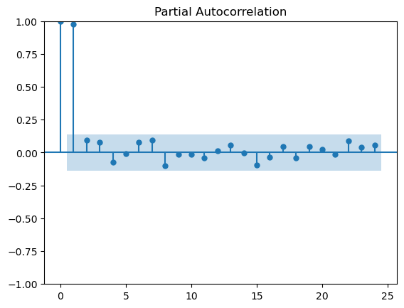

```python
sm.graphics.tsa.plot_pacf(shelter_data.values)
plt.show()
```

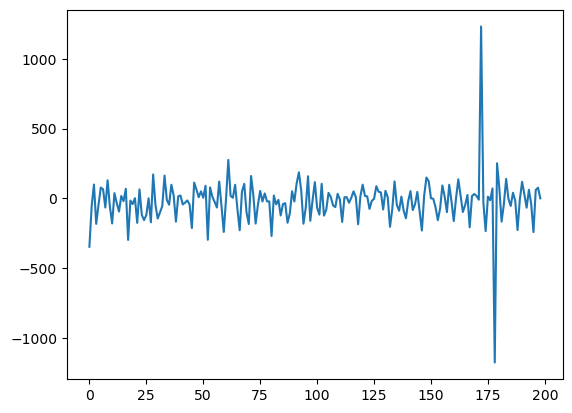

```python
shelter_diff = np.diff(shelter_data.values)
plt.plot(shelter_diff)
```

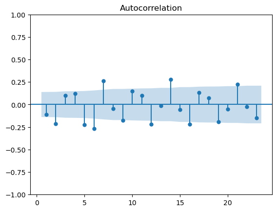

```python
sm.graphics.tsa.plot_acf(shelter_diff, zero=False)
plt.show()
```

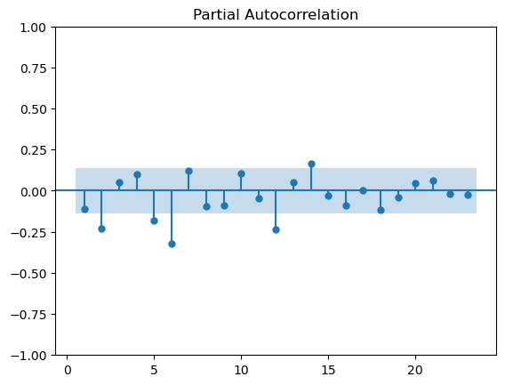

```python
sm.graphics.tsa.plot_pacf(shelter_diff, zero=False)
plt.show()
```

Let's try to fit one with the statsmodels package

```python
model = sm.tsa.arima.ARIMA(shelter_data, order=(0, 1, 0))
results = model.fit()
print(results.summary())
```

```
                                    SARIMAX Results
========================================================================================
Dep. Variable:     Total Individuals in Shelter   No. Observations:                  200
Model:                           ARIMA(0, 1, 0)   Log Likelihood               -1293.886
Date:                          Tue, 13 Sep 2022   AIC                           2589.772
Time:                                  13:22:50   BIC                           2593.065
Sample:                                       0   HQIC                          2591.105
                                          - 200
Covariance Type:                            opg
==============================================================================
                 coef    std err          z      P>|z|      [0.025      0.975]
------------------------------------------------------------------------------
sigma2        2.6e+04    662.352     39.260      0.000    2.47e+04    2.73e+04
===================================================================================
Ljung-Box (L1) (Q):                   2.50   Jarque-Bera (JB):              7679.54
Prob(Q):                              0.11   Prob(JB):                         0.00
Heteroskedasticity (H):               3.80   Skew:                             0.44
Prob(H) (two-sided):                  0.00   Kurtosis:                        33.42
===================================================================================

Warnings:
[1] Covariance matrix calculated using the outer product of gradients (complex-step).
```

```
([], [])
```

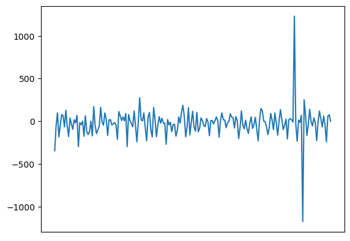

```python
plt.plot(results.resid[1:])
plt.xticks([], [])
```

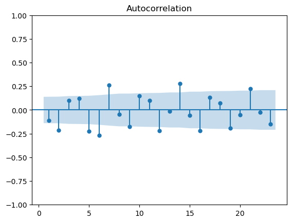

```python
sm.graphics.tsa.plot_acf(results.resid[1:], zero=False)
plt.show()
```

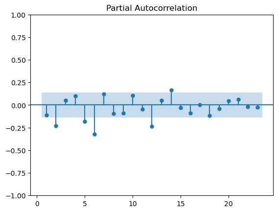

```python
sm.graphics.tsa.plot_pacf(results.resid[1:], zero=False)
plt.show()
```